# Upgrading in Global Value Chains

Erol Taymaz  
Department of Economics  
Middle East Technical University

13 December 2017

# Outline

- Globalization and value chains
- Upgrading in Global Value Chains
- A new method for identifying value chains
- GVC metrics
  - Complexity
  - Upstreamness
  - Specialization
- Upstreamness and productivity

# Globalization

- Increasing integration of national economies
  - A rapid increase in international trade
    - Export/GDP and Import/GDP ratios tend to increase
  - A rapid increase in FDI
  - A rapid increase in off-shoring (vertical FDI and out-sourcing)
- Global production
  - Global/international/production networks
  - Global supply chains
  - Global value chains (Gereffi)

# Global value chains

- GVC: The sequence of productive (i.e., value-added) activities leading to end use
  - Encompasses all activities that are required to bring a product or service from conception to delivery to final consumers, and final disposal after use.
  - Emphasizes the process of value creation, i.e., the analysis goes beyond production of goods and services.
  - Incorporates spatial aspects and scales (local, national, regional and global) over the “whole-of the-supply-chain”.

# Global trade (exports of goods and services), by type of TNC involvement, 2010

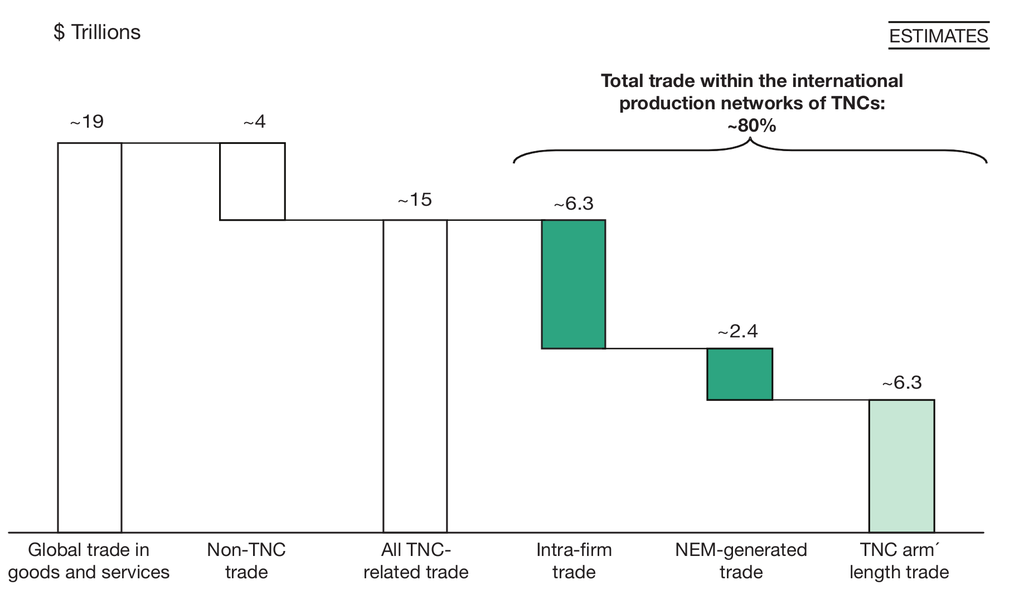

Source: UNCTAD, 2013: 16.

# GVC participation, 1995 and 2009

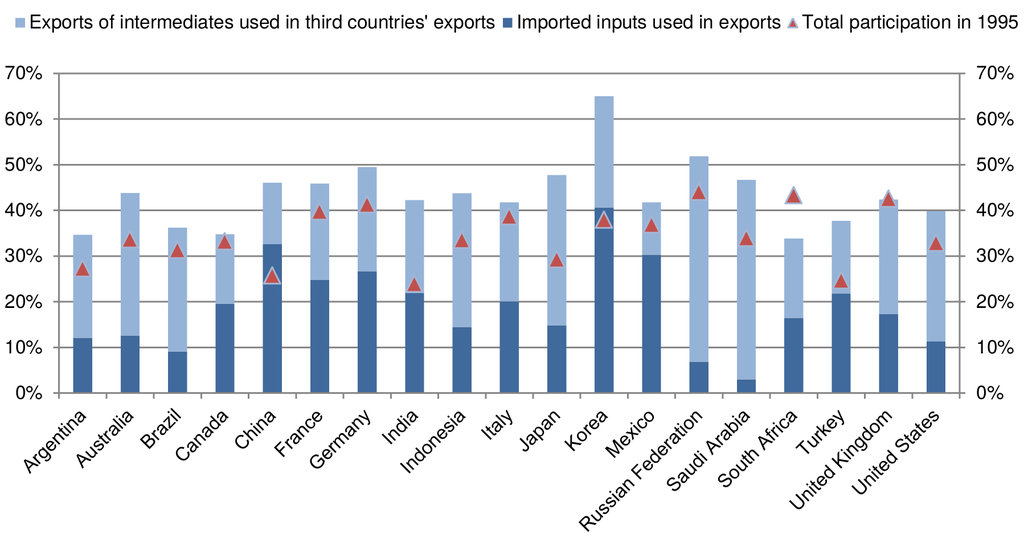

Source: OECD, WTO and World Bank (2014: 14)

# Domestic value added trade shares of the top 25 developing economy exporters, 2010

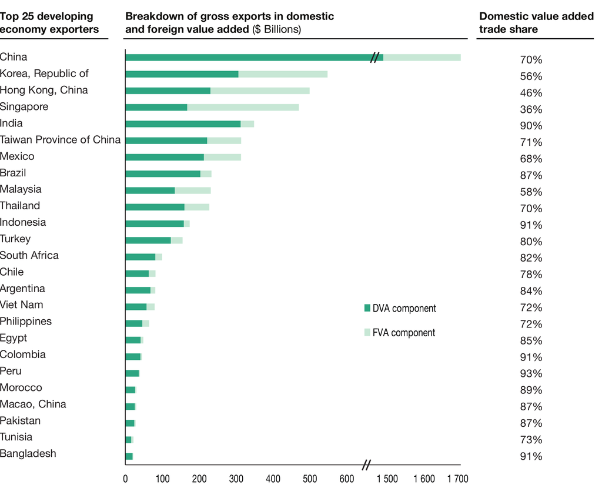

Source: UNCTAD (2013: 14)

**Foreign value added share** (foreign value added as a share of exports) indicates what part of a country’s gross exports consists of inputs that have been produced in other countries.

**Domestic value added share** (the share of the country’s value added incorporated in third countries gross exports) can be used as an indicator for the extent of participation in downstream activities.

**GVC participation** is simply the sum of foreign and domestic value added shares.

# Share of foreign value added in exports, selected industries, 2010

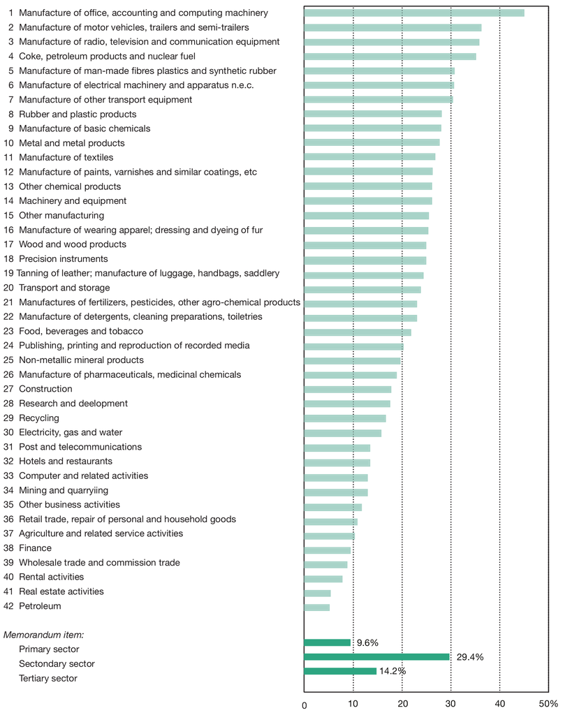

Source: UNCTAD (2013: 7)

# Trends in value added trade

- World value-added exports are equal to about 70-75 percent of gross exports today, down from about 85 percent in the 1970s and 1980s.
- Manufacturing trade is relatively smaller, and services trade relatively larger, when measured in value-added terms.
- Across countries, value-added exports range from 50 to 90 percent of the value gross exports.
- Gaps between bilateral value-added and gross exports are large and heterogeneous across trade partners.
- Changes in value-added relative to gross exports have been heterogeneous across countries and bilateral trade partners.

# Global Value Chains and productivity

- GVCs arise as a result of slicing up the production chain, and relocating activities across countries.
- Value will be accumulated through consecutive stages of production.
- However, each stage may require different sets of capabilities and techniques, and allow to add amount of value.

# Stages of production and value chain

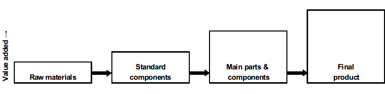

# Value added in textile/clothing value chain (2005-2007 average values)

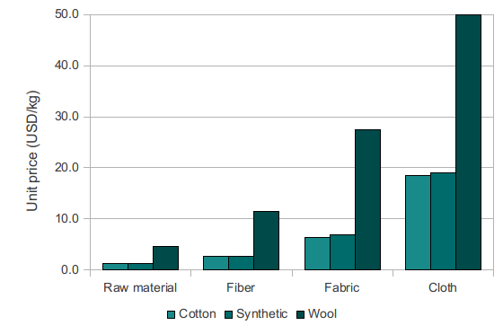

Source: Taymaz, Yilmaz, and Voyvoda (2011: 155)

# The TOSP framework

- Different stages of production have different amount value added.
- The value chain can be conceptualized at four layers: products, stages, occupations, and tasks.
- At the bottom is the product, which is conceived of as including after sales services.
- At the top are tasks – the full list of everything that must be done to get the product into consumers’ hands and provide them with associated after-sales services.
- The production process can be divided into certain stages that need certain occupations to be performed.
- Each occupation performs a set of task that determine the value added by that occupation.
- The value added share of those tasks that are complex and require skilled labor is higher than those tasks that only need unskilled labor.

# The TOSP framework

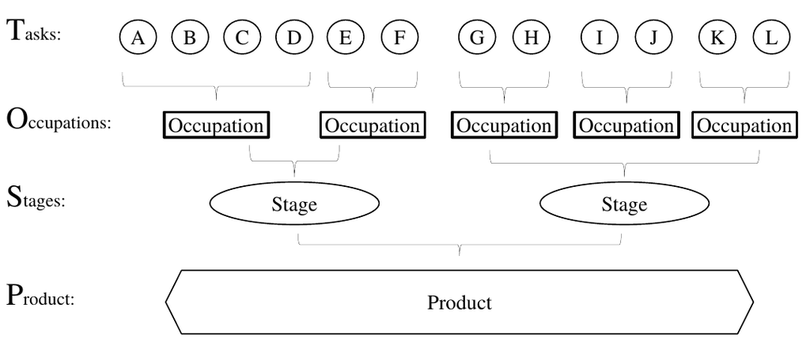

Source: Baldwin (2013)

# The “Smile Curve”: Good and bad stages in the value chain

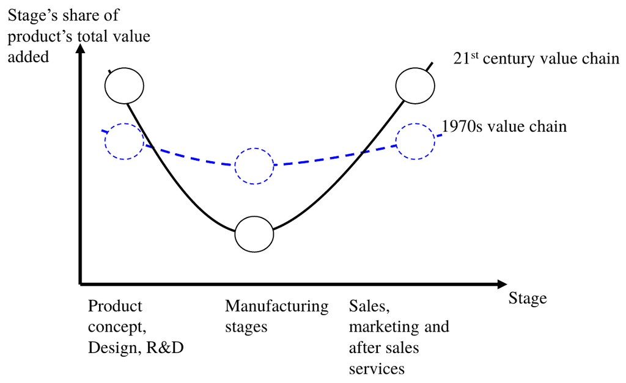

Source: Baldwin (2013)

Different stages of production process can be spread geographically depending on the costs and benefits of scattering stages of production. The benefits of dispersion increases with the diversity of production conditions in various countries (most notable by differences in labor costs) whereas the decline in coordination and transportation costs facilitates the dispersion of the production process.

# Upgrading in Global Value Chains

- **Process upgrading:** Firms can increase their productivity by using their resources more efficiently and effectively. For example, process upgrading may involve replacement of craft production by mass production, and then mass production by lean (or just-in-time) production.
- **Product upgrading:** Firms can increase their productivity my moving into more sophisticated product lines. The “sophistication level”" of a product can be measured by unit value, labor productivity or task content.
- **Functional upgrading:** Functional upgrading implies opportunities within the existing value chain (for this reason, it is also called “intra-chain upgrading”"). For example, firms can increase their productivity by acquiring new functions (or abandoning existing functions) to move towards skilled labor intensive activities. In such a case, firms move backward or forward to different stages in a supply chain, such as moving from the production of finished goods to intermediates or raw materials (upgrading via vertical integration). In more advanced cases, the firm could move towards performing R&D and design activities, or producing for brand-name clients or even marketing under its own brand name.
- **Chain upgrading:** In this case, the firm moves into new (and related) value chains that are more productive (this is also called “inter-chain upgrading”). In this type of upgrading, the firm applies the competence acquired in a particular function of a chain to a new sector.

# Upgrading as a linear process

GVC researchers tend to view “upgrading” as a linear process starting with “process upgrading”, then moving on to “product upgrading”, and finally on to “intra-chain” and/or “inter-chain” upgrading.

But it is questionable…

# Global Value Chains as a linear relationship

- Final producers
- Tier 1 suppliers
- Tier 2 suppliers
- Tier 3 suppliers

This is also questionable…

# How to identify a Global Value Chain

- Identify individual products of specific GVCs
- Identify value chains from IO tables
  - OECD, TiVA (Trade in Value Added)
    - Use national and international IO tables
    - Aggregated value chains

# Identification of GVCs

- Identify all GVCs (at the product level)
  - Use US IO table
    - The most detailed one (389 sectors)
    - The largest and most diversified economy in the world
- Calculate the complexity of GVCs
- Find the level of upstreamness of each product
- Analyze the upgrading process for all GVCs

# Identification of GVCs

*IO* matrix for commodity *i*

$IO_i = B*diag((I - B)^{-1}e_i)$

where *B* is commodity-by-commodity input coefficients matrix, *I* the identity matrix, and *e* a column vector of outputs (i’th element is equal to 1, all others zero). diag(.) is the diagonal function.

# GVC metrics

- Complexity (GVC)
  - $C = f(n_E, n_L)$
- Upstreamness (sector)
  - $U_i = \Sigma_j w_{ij}(1 + U_j)$
- Specialization (sector)
  - $S_i = \Sigma_j h^2_{ij}$

# Motor vehicle chain

[figure not shown]

# Motor vehicle gasoline engine chain

[figure not shown]

# Cement chain

[figure not shown]

# Ready-mix concrete chain

[figure not shown]

# Guided-missile & space vehicle chain

[figure not shown]

# Ice cream chain

[figure not shown]

# Upstreamness

- Find the weighted average of upstreamness for all relevant products

|  | names | upstreamness |
| --- | --- | --- |
| 1 | Automobile manufacturing | 1.001 |
| 2 | Tire manufacturing | 2.001 |
| 3 | Motor vehicle body manufacturing | 2.002 |
| 4 | Motor vehicle gasoline engine | 2.003 |
| 5 | Glass and glass product manufacturing | 2.003 |
| 6 | Audio and video equipment | 2.004 |
| 7 | Motor vehicle transmission | 2.006 |
| 8 | Motor vehicle steering | 2.011 |
| 9 | Motor vehicle seating | 2.011 |
| 10 | Other motor vehicle parts | 2.015 |
| 11 | Motor vehicle electrical and electronic equipment | 2.016 |
| 12 | Paperboard container manufacturing | 2.016 |
| 13 | Motor vehicle metal stamping | 2.018 |
| 14 | Other plastics products | 2.025 |
| 15 | Copper rolling, drawing, extruding | 3.150 |
| 16 | Petroleum refineries | 3.837 |
| 17 | Other basic organic chemicals | 4.020 |
| 18 | Petrochemical manufacturing | 4.025 |
| 19 | Oil and gas extraction | 4.872 |

# Upstreamness

[figure not shown]

# Further research

- Measurement of GVC metrics (complexity, specialization, centrality, etc.)
- Occupational structure of sectors
- Upgrading in GVCs through international trade